# Automated and general reader of Nonmem data

Built 2021-06-14 using NMdata 0.0.7.2.908.

## Introduction

Preparing data for analysis in Nonmem and reading the results back into `R` can be time consuming. After a Nonmem run, a few tables may have to be combined. Then we need character variables that are only available in the input data file. And maybe the events ignored by Nonmem (say, observations below quantification limit that we still need in further analysis and plotting).

This vignette focuses on how to use `NMdata` to automate what needs to be trivial: get a dataset out of a Nonmem run, including discarded columns and rows from the input data. In brevity, the most important steps are

- Read and combine output tables
- If wanted, read input data and restore variables that were not output from the Nonmem model
- If wanted, also restore rows from input data that were disregarded in Nonmem (e.g. observations or subjects that are not part of the analysis)

In most cases, this is not too hard to do. But with the large degree of flexibility Nonmem offers, the code will likely have to be adjusted between models, and there are a lot of caveats to be aware of. The implementation in `NMdata` works for the vast majority of models and aims at preventing and checking for as many caveats as possible. It is fast and default argument values can be configured depending on your setup (data standards, directory structure and other preferences).

Like the rest of `NMdata`, this functionality assumes as little as possible about how you work. It assumes nothing about the Nonmem model itself and as little as possible about the organization of data and file paths/names. This makes it powerful for meta analyses, for reading a model developed by someone else - or one written by ourselves when we used to do things slightly differently. It will work out of the box in the vast majority of cases.

We start by attaching `NMdata`. I’m a `data.table` user and use that for a few postprocessing steps. You can just as well use base R or `dplyr` if you prefer. Then `ggplot2` for illustrations.

```r
library(NMdata)
## not necessary for NMdata to run, but we use thse in the examples
library(data.table)
library(ggplot2)
theme_set(theme_bw()+theme(legend.position="bottom"))
```

For the examples we will be using files that are available in the `NMdata` package. To type a little less, we use this shortcut function:

```r
file.NMdata <- function(...) system.file(file.path("examples/nonmem",...), package="NMdata")
```

## Get started - the basics

Try `NMscanData` on a control stream or a list file:

```r
res1 <- NMscanData(file.NMdata("xgxr018.lst"))
```

```
#> Model:  xgxr018
#> Input and output data combined by translation of
#> Nonmem data filters (not recommended).
#>
#> Used tables, contents shown as used/total:
#>                  file     rows columns     IDs
#>       xgxr018_res.txt  905/905     7/7 150/150
#>  xgxr018_res_vols.txt  905/905     3/7 150/150
#>    xgxr018_res_fo.txt  150/150     1/2 150/150
#>     xgxr4.csv (input) 905/1502   21/23 150/150
#>
#> Distribution of rows on event types in returned data:
#>  EVID Output
#>     0    755
#>     1    150
```

In the resulting data, 755 out of the 905 rows are `EVID==0`, the remaining 150 rows are `EVID==1`.

Let’s take a quick look at key properties of the data that was returned. It’s a `data.frame` with the additional `NMdata` class (for now, we just use it as a `data.frame`).

```r
class(res1)
```

```
#> [1] "NMdata"     "data.frame"
```

```r
dim(res1)
```

```
#> [1] 905  34
```

The data used for the example is a PK single ascending dose data set, great thanks to the [xgxr](https://cran.r-project.org/web/packages/xgxr/index.html) package authors.

The obtained dataset contains both model predictions (i.e. from output tables) and a character variable, `trtact` (i.e. from input data). To the `.lst` (output control stream) file path was supplied by us.

```r
head(res1,n=2)
```

```
#>   ROW ID NOMTIME TIME EVID CMT AMT DV FLAG STUDY     KA
#> 1   1 31       0    0    1   1   3  0    0     1 0.1812
#> 2  11 32       0    0    1   1   3  0    0     1 0.1812
#>         Q PRED RES WRES    V2     V3 BLQ CYCLE DOSE PART
#> 1 2307400    0   0    0 0.042 0.1785   0     1    3    1
#> 2 2307400    0   0    0 0.042 0.1785   0     1    3    1
#>   PROFDAY PROFTIME WEIGHTB   EFF0        CL EVENTU   NAME
#> 1       1        0  87.031 56.461 0.7245691     mg Dosing
#> 2       1        0 100.620 45.096 0.7245691     mg Dosing
#>   TIMEUNIT TRTACT   flag trtact   model nmout
#> 1    Hours   3 mg Dosing   3 mg xgxr018  TRUE
#> 2    Hours   3 mg Dosing   3 mg xgxr018  TRUE
```

### What will NMscanData return?

The following main principles are followed by `NMscanData`:

- Priority of data
  - Output data prevails over input data
  - Row-specific output data is preferred over ID-level (`FIRSTONLY` or `LASTONLY`) tables
  - Output tables are prioritized by their order of appearance (order of $TABLE sections)
  - The primary aim is to return the output data. If input and output cannot be meaningfully combined (very rare), output will be returned.
- Properties of returned data if input data used (`use.input=TRUE`)
  - Input data column names will be default be returned as defined in the `$INPUT` section in Nonmem.
  - Columns that are dropped in Nonmem (`DROP` or `SKIP`) are included by `NMscanData`.
  - Columns that are not included in `$INPUT` are named as in the input data file.
  - If rows are being recovered from input data (the `recover.rows` argument), no information from output is merged onto these rows.

Once you have data from `NMscanData`, `NMinfo` can be used to browse meta information on what data was combined and how that was done.

### Use a unique row identifier

Above, we were told that “Input and output data combined by translation of Nonmem data filters (not recommended).” Because of the very commonly used `ACCEPT` and `IGNORE` statements in Nonmem `$DATA` sections, the rows in output tables are often a subset of the input data rows. If no other information is available, `NMscanData` reads and interprets the `ACCEPT` or `IGNORE` statements and applies them to the input data before combining with the output data.

A more robust approach is using a unique row identifier in both input data and output data. `NMscanData` can use this for merging the data. This means that the `ACCEPT` or `IGNORE` are not interpreted at all. Even though `NMscanData` should work even without, it is always recommended to always include a unique row identifier in both input and output tables (in fact, we just need it in one full-length output table).

The following model happens to have such a unique row identifier in the column called `ROW`. The default `NMscanData` behavior is to use the row identifier if it can find it. The name of the column with the row identifier can be supplied using the `col.row` argument (and the default can be changed using the `NMdataConf` function). The default is to look for `ROW`.

All features shown below will work whether you supply `col.row` or not. We use `col.row` because it is more robust and because it allows us to easily trace a row in the analysis back to the source data. We are now told that the data was merged by `ROW` - that’s better.

```r
res1.tbl <- NMscanData(file.NMdata("xgxr003.lst"),as.fun=tibble::as_tibble)
```

```
#> Model:  xgxr003
#> Input and output data merged by: ROW
#>
#> Used tables, contents shown as used/total:
#>                  file     rows columns     IDs
#>       xgxr003_res.txt  905/905     7/7 150/150
#>  xgxr003_res_vols.txt  905/905     3/7 150/150
#>    xgxr003_res_fo.txt  150/150     1/2 150/150
#>     xgxr1.csv (input) 905/1502   21/24 150/150
#>
#> Distribution of rows on event types in returned data:
#>  EVID Output
#>     0    755
#>     1    150
```

### Get your preferred data class back from `NMscanData`

When reading `res1.tbl`, we also added the `as.fun` argument. the “`as.`” refers to `as_tibble`, `as.data.frame`, `as.data.table` etc. - a function applied to the data before it’s returned by `NMscanData` (or any other `NMdata` function). So now we have a `tibble`:

```r
class(res1.tbl)
```

```
#> [1] "NMdata"     "tbl_df"     "tbl"        "data.frame"
```

I happen to be a `data.table` user so I am more comfortable working that way. Instead of using the `as.fun` all the time, we will change the default behavior using the `NMdataConf` function. Because `NMdata` is implemented in `data.table` we don’t need to pass the `data.table::as.data.table` function but we can (better) use the string `"data.table"` (again, `data.table` is the exception - for anything else, please pass a function):

```r
NMdataConf(as.fun="data.table")
```

Notice, `NMdataConf` will set the default value for all `NMdata` functions that use that argument. So when setting `as.fun` this way, we will get the desired class returned from all data generating `NMdata` functions.

We don’t want the same information about the dimensions repeated, so we use the `quiet` argument this time.

```r
res1.dt <- NMscanData(file.NMdata("xgxr003.lst"),quiet=TRUE)
```

As expected we got a `data.table` this time:

```r
class(res1.dt)
```

```
#> [1] "NMdata"     "data.table" "data.frame"
```

### Browse the metadata

An `NMdata` object returned by `NMscanData` comes with meta information about when and how what was read, and how the data was combined. The `NMinfo` function browses this information, and three options are available. It provides three sections of meta data:

- “details”: A list including the function call, what options were effective (if input was included, rows recovered, if data was merged by a row identifier or combined by filters etc).
- “tables”: Overview of the tables that were read and combined by `NMscanData` and properties of the different tables.
- “columns”: Information on the columns that were treated by `NMscanData` (see example below).

The follwing show the “columns” information as example. Remember, we are still getting a data.table because we used `NMdataConf` to change the configuration. We use the `data.table` print function to only look at first and last ten rows.

```r
print(NMinfo(res1,info="columns"),nrows=20,topn=10)
```

```
#>     variable                 file     source level COLNUM
#>  1:      ROW      xgxr018_res.txt     output   row      1
#>  2:       ID xgxr018_res_vols.txt     output   row      2
#>  3:  NOMTIME            xgxr4.csv      input   row      3
#>  4:     TIME            xgxr4.csv      input   row      4
#>  5:     EVID            xgxr4.csv      input   row      5
#>  6:      CMT            xgxr4.csv      input   row      6
#>  7:      AMT            xgxr4.csv      input   row      7
#>  8:       DV      xgxr018_res.txt     output   row      8
#>  9:     FLAG            xgxr4.csv      input   row      9
#> 10:    STUDY            xgxr4.csv      input   row     10
#> ---
#> 32:   trtact            xgxr4.csv      input   row     32
#> 33:    model                 <NA> NMscanData model     33
#> 34:    nmout                 <NA> NMscanData   row     34
#> 35:       DV xgxr018_res_vols.txt     output   row     NA
#> 36:     PRED xgxr018_res_vols.txt     output   row     NA
#> 37:      RES xgxr018_res_vols.txt     output   row     NA
#> 38:     WRES xgxr018_res_vols.txt     output   row     NA
#> 39:       ID            xgxr4.csv      input   row     NA
#> 40:       DV            xgxr4.csv      input   row     NA
#> 41:       ID   xgxr018_res_fo.txt     output    id     NA
```

The column names are sorted by the order in the resulting dataset, the order given by the `COLNUM` column. The variables in the bottom that have `COLNUM==NA` were redundant when combining the data (the same columns were included from other sources). The file names and their source (input/output) and a “level” are given. “level” is the information level of the source. Input data and full-length output tables are “row” level, a firstonly or lastonly table is id-level. And then there is the `model` column added by `NMscanData` which is obviously model-level. `nmout` is the other column added by `NMscanData` and both `model` and `nmout` have `NA` file and `NMscanData` as source.

## More options and features

Let’s have a quick look at the data we got back. The following is done with `data.table`. The comments in the code should make it clear what happens if you are not familiar with `data.table`. You can do this with `base::tapply`, `stats::aggregate`, a combination of `dplyr::group_by` and `dplyr::summarize`, or whatever you prefer.

`gmPRED` is calculated for sample times only and represents the geometric mean of population prediction (`PRED`) by dose and nominal time.

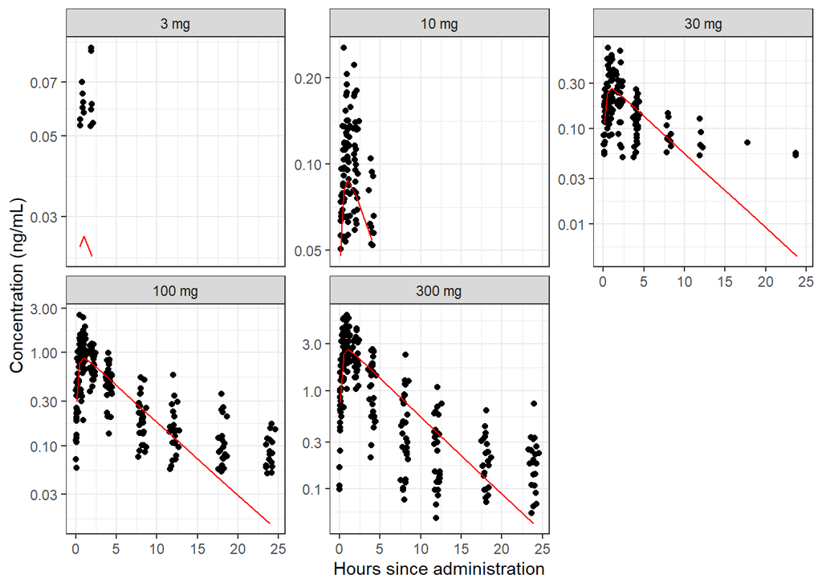

```r
## trtact is a character. Make it a factor with levels ordered by
## numerical dose level. The := is a data.table assignment within
## res3. In dplyr, you could use mutate.
res1.dt[,trtact:=reorder(trtact,DOSE)]
## Derive geometric mean pop predictions by treatment and nominal
## sample time. In dplyr, use group_by, summarize, and ifelse?
res1.dt[EVID==0,gmPRED:=exp(mean(log(PRED))),
     by=.(trtact,NOMTIME)]
```

Notice, how little data is shown on the small doses. Remember, only 905 of the 1502 rows in the input data were used? Most of the rows excluded in the analysis are so due to observation being below the quantification limit (BLQ). The next section shows how to recover all the input data rows with `NMscanData`.

### Recover rows

We may want to include the input data that was ignored by Nonmem. Use `recover.rows=TRUE` to include all rows from input data.

```r
res2 <- NMscanData(file.NMdata("xgxr014.lst"),recover.rows=TRUE)
```

```
#> Model:  xgxr014
#> Input and output data merged by: ROW
#>
#> Used tables, contents shown as used/total:
#>               file      rows columns     IDs
#>    xgxr014_res.txt   905/905   12/12 150/150
#>  xgxr2.rds (input) 1502/1502   22/24 150/150
#>
#> Distribution of rows on event types in returned data:
#>  EVID Input only Output
#>     0        597    755
#>     1          0    150
```

Besides the `model` column holding the model name, `NMscanData` creates one other column by default. `nmout` is a boolean column created by `NMscanData` expressing whether each row was in the output data (`nmout==TRUE`) or they were recovered from the input data (`nmout==FALSE`).

We recognize these numbers from the message from `NMscanData` - the number of rows in output (905) and number of rows from input only (597). Since we changed the default value of `as.fun` with `NMdataConf`, `res2` is a `data.table`.

```r
res2[,.N,by=nmout]
```

```
#>    nmout   N
#> 1:  TRUE 905
#> 2: FALSE 597
```

We make use of the `nmout` column to only calculate `gmPRED` for observations (`EVID==0`) processed by Nonmem.

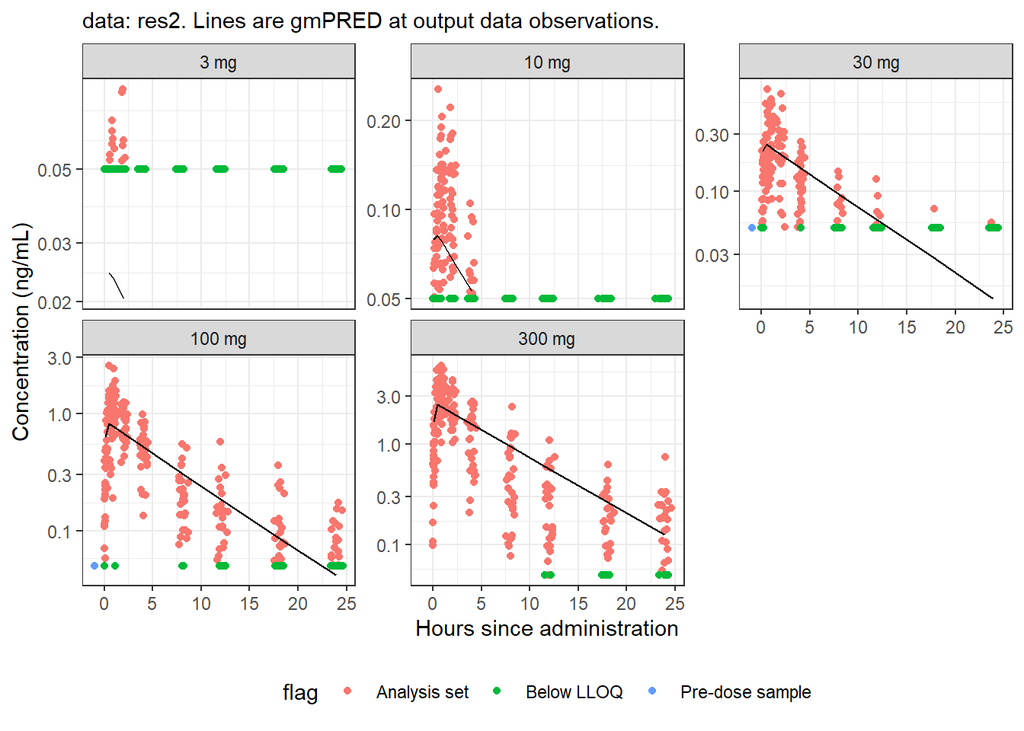

```r
## add geometric mean pop predictions by treatment and nominal sample
## time. Only use sample records.
res2[EVID==0&nmout==TRUE,
     gmPRED:=exp(mean(log(PRED))),
     by=.(trtact,NOMTIME)]
```

Obviously, we were lucky that meaningful values were assigned to `DV` for the BLQ and pre-dose samples in input data, so we in this case could easily plot all the data.

### Combine multiple models

`NMscanData` by default adds a column called `model` for convenience when working with multiple models. You can specify both column name (which is by `model` default) and model name (contents of that column) as arguments in `NMscanData`. Using `NMdataConf`, You can also configure the default column name and the function that generates the model name.

The default is to derive the model name from the `lst` file name (say, `xgxr001.lst` becomes `xgxr001`). In the following we use this to compare population predictions from two different models. We read them again just to show the use of the argument to name the models ourselves. Remember, we configure `NMdata`’s `as.fun` option so we are working with `data.table` and we easily stack with `rbind` (`rbind.data.table`) filling in `NA`’s. We add a couple of options to specify how input and output data are to be combined.

```r
NMdataConf(as.fun="data.table", ## already set above, repeated for completeness
           col.row="ROW",       ## This is default, included for completeness
           merge.by.row=TRUE    ## Require input and output data to be combined by merge
           )
```

```r
res1.m <- NMscanData(system.file("examples/nonmem/xgxr001.lst", package="NMdata"),
                     quiet=TRUE)
## using a custom modelname for this model
res2.m <- NMscanData(system.file("examples/nonmem/xgxr014.lst", package="NMdata"),
                     modelname="One compartment",
                     quiet=TRUE)
## notice fill is an option to rbind with data.table (like bind_rows in dplyr)
res.mult <- rbind(res1.m,res2.m,fill=T)
## Notice, the NMdata class disappeared
class(res.mult)
```

```
#> [1] "data.table" "data.frame"
```

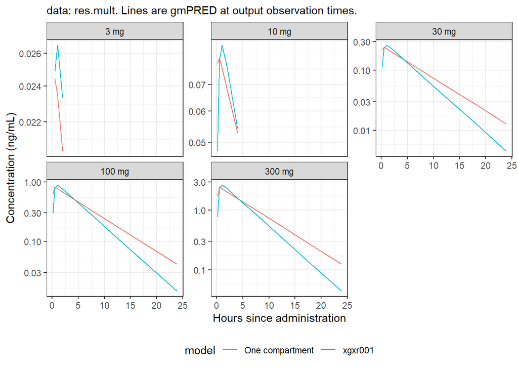

```r
res.mult[EVID==0&nmout==TRUE,
         gmPRED:=exp(mean(log(PRED))),
         by=.(model,trtact,NOMTIME)]
```

In this, we specifically wanted to rename one model for illustration of the `modelname` argument. We can pass a function to customize how `NMscanData` derives it from the list file path. This one skips the characters and leading zeros, so we just get an integer. We could pass use the `modelname` argument in `NMdata` but why not changed the default instead?

```r
namefun <- function(path) sub("^[[:alpha:]0]+","",fnExtension(basename(path),""))
NMdataConf(modelname=namefun)
res1.m <- NMscanData(system.file("examples/nonmem/xgxr001.lst", package="NMdata"),
                     quiet=TRUE)
res2.m <- NMscanData(system.file("examples/nonmem/xgxr014.lst", package="NMdata"),
                     quiet=TRUE)
## notice fill is an option to rbind with data.table (like bind_rows in dplyr)
res.mult <- rbind(res1.m,res2.m,fill=T)
res.mult[,.N,by=model]
```

```
#>    model   N
#> 1:     1 905
#> 2:    14 905
## resetting default
```

```r
NMdataConf(modelname=NULL)
```

`NMdataConf` can be used to change a lot of the default behaviour of the functions in `NMdata` so it fits in with your current setup and preferred work flow.

### Preserve all input data properties - use `rds`

Return to the example above creating the dataset `res22`. Notice in the list of tables in the message from `NMscanData`, that input data was a `.rds` file. This is why we could sort the plots correctly on the dose level without reordering the factor levels first.

```r
res2[,class(trtact)]
```

```
#> [1] "factor"
```

```r
res2[,levels(trtact)]
```

```
#> [1] "Placebo" "3 mg"    "10 mg"   "30 mg"   "100 mg"
#> [6] "300 mg"
```

If the argument `use.rds` is `TRUE`, `NMscanData` will look for an rds file next to the input data file (which is a delimited text file) the exact same name as the text file except the extension must be `.rds` rather than say `.csv` (for Nonmem and `NMscanData`, the extension of the delimited text file doesn’t matter). If it finds the `rds` file, this will be used instead. No checks are done of whether the contents are similar in any way to the delimited text file which is ignored in this case.

There are three advantages of using `rds` files:

- All attributes are kept. This includes column classes and factor levels.
- Reading speed may be improved (NMdata uses `fread` from `data.table` which is extremely fast for delimited files so in many cases this difference can be small).
- File sizes are greatly reduced from text to `rds`. This can be a big advantage if you are transfering files or reading over a network connection. `NMdata` is generally very fast (thanks to `data.table`) so file/network access (I/O) is likely to be the main bottleneck.

If you write Nonmem datasets with the `NMdata::NMwriteData`, you can get an `rds` file automatically, exactly where `NMscanData` will look for it. Creating datasets using `NMdata` is described in [this vignette](https://philipdelff.github.io/NMdata/articles/DataCreate.html).

You probably want to use `NMdataConf` to change the default behavior if you don’t want to use `rds` files.

## Reading data without automatically combining it - the `NMscaData` building blocks

Each of the steps involved in reading and combining the data from a model run can be done separately.

The `lst` file was scanned for output tables, and they were all read (including interpreting the possible `firstonly` option). The input data has been used based on the `$DATA` and `$INPUT` sections of the control stream. The key steps in this process are available as independent functions.

- `NMreadTab`: Read an Nonmem output table based on the path to the output table file.
- `NMscanTables`: Read all output data files defined in a Nonmem run. Return a list of tables (as data.frames or data.tables).
- `NMtransInput`: Read input data based on a Nonmem file. Data will be processed and named like the Nonmem model. `ACCEPT` and `IGNORE` filters can be applied as well. There are a few limitations to this functionality at this point. More about them below.

## What should I do for my models to be compatible with NMscanData?

The answer to this should be as close to “nothing” as possible - that’s more or less the aim of the function. You just have to make sure that the information that you need is present in input data and output data. No need to output information that is unchanged from input, but make sure to output what you need (like `IPRED`, `CWRES`, `CL`, `ETA1` etc which cannot be found in input). Some of these values can be found from other files generated by Nonmem but notice: `NMscanData` uses only input and output data.

It is recommended to always use a unique row identifier in both input and output data. This is the most robust way to merge back with input data. In firstonly tables, include the subject ID. Again, everything will most likely work even if you don’t, I personally don’t like relying on “most likely” when I can just as well have robustness.

## Limitations

Even if there are a few limitations to what models `NMscanData` can handle, there is a good chance you will never run into any of them, as they are mostly quite rare. If you do, reach out to me, and we’ll figure it out.

### Input data file must exist and be unmodified since model run

If merging with input data, the input data must be available as was when the model was run. If you want to avoid this potential issue, Nonmem can be run in a wrapper script that either copies the input data, or runs `NMscanData` and saves the output in a compressed file format (like `rds` or `zip`).

### Not all data filter statements implemented

Nested `ACCEPT` and `IGNORE` statements are not supported at this point. The resulting number of rows after applying filters is checked against row-level output table dimensions (if any available). In other words, you have to be unlucky to run into trouble without an error. But it is always recommended to use a unique row identifier in both input and output tables in order to avoid relying on interpretation of Nonmem code.

The `RECORDS` and `NULL` options in `$DATA` are not implemented. If using `RECORDS`, please use the `col.row` option to merge by a unique row identifier.

### Character time variables not interpreted

Nonmem supports a clocktime input format for a column called TIME in input data. Based on a day counter and a character (“00:00”) clock format, Nonmem (or rather, `NM-TRAN`) can calculate the individual time since first record. This behaviour is not mimicked by NMscanData, and the only ways to get TIME in this case are to either include it in an output `TABLE` or to code the translation yourself after calling `NMscanData`. Of course, this is on the todo list.

### Some TABLE options not supported

For now, only output tables returning either all rows or one row per subject can be merged with input. Tables written with options like `FIRSTLASTONLY` (two rows per subject) and `OBSONLY` are disregarded with a warning (you can read them with `NMscanTables`). `LASTONLY` is treated like `FIRSTONLY`, i.e. as ID-level information if not available elsewhere.

## Custom naming of input and output control streams

By default, `NMscanData` expects a [PSN](https://uupharmacometrics.github.io/PsN/)-style naming of input and output control streams. This means that if the input control stream is called `model.mod`, the returned control stream is called `model.lst`. If you use a different setup, you can use the `file.mod` argument. Do one of the following if needed:

- Explicitly give the path to the input control stream or
- Pass a function that translates from the output control stream to the input. Example if the input is called `input.txt` and the output is called `output.txt`:

```r
out2in <- function(file) file.path(dirname(file),"input.txt")
res <- NMscanData("path/to/output.txt",file.mod=out2in)
```

You can use `NMdataConf` to configure the default behaviour to match your setup:

```r
NMdataConf(file.mod=out2in)
```